# Practical Machine Learning-Writeup

October, 2015

## Synopsis

Using devices such as Jawbone Up, Nike FuelBand, and Fitbit it is now possible to collect a large amount of data about personal activity relatively inexpensively. These type of devices are part of the quantified self movement  a group of enthusiasts who take measurements about themselves regularly to improve their health, to find patterns in their behavior, or because they are tech geeks. One thing that people regularly do is quantify how much of a particular activity they do, but they rarely quantify how well they do it. In this project, your goal will be to use data from accelerometers on the belt, forearm, arm, and dumbell of 6 participants. They were asked to perform barbell lifts correctly and incorrectly in 5 different ways.

More information is available from the website here: http://groupware.les.inf.puc-rio.br/har (see the section on the Weight Lifting Exercise Dataset).

Data The training data for this project are available here: https://d396qusza40orc.cloudfront.net/predmachlearn/pml-training.csv

The test data are available here: https://d396qusza40orc.cloudfront.net/predmachlearn/pml-testing.csv

The data for this project come from this source: http://groupware.les.inf.puc-rio.br/har.

The goal of your project is to predict the manner in which they did the exercise. This is the “classe” variable in the training set which classifies the outcomes into one of the categories A, B, C, D, or E.

## Retrieve and clean data

1. Download data
2. Read csv file

```r
training <- read.csv("pml-training.csv")
testing<- read.csv("pml-testing.csv")
```

Show Data Structure

```r
str(training, list.len=20)
```

```
## 'data.frame':    19622 obs. of  160 variables:
##  $ X                       : int  1 2 3 4 5 6 7 8 9 10 ...
##  $ user_name               : Factor w/ 6 levels "adelmo","carlitos",..: 2 2 2 2 2 2 2 2 2 2 ...
##  $ raw_timestamp_part_1    : int  1323084231 1323084231 1323084231 1323084232 1323084232 1323084232 1323084232 1323084232 1323084232 1323084232 ...
##  $ raw_timestamp_part_2    : int  788290 808298 820366 120339 196328 304277 368296 440390 484323 484434 ...
##  $ cvtd_timestamp          : Factor w/ 20 levels "02/12/2011 13:32",..: 9 9 9 9 9 9 9 9 9 9 ...
##  $ new_window              : Factor w/ 2 levels "no","yes": 1 1 1 1 1 1 1 1 1 1 ...
##  $ num_window              : int  11 11 11 12 12 12 12 12 12 12 ...
##  $ roll_belt               : num  1.41 1.41 1.42 1.48 1.48 1.45 1.42 1.42 1.43 1.45 ...
##  $ pitch_belt              : num  8.07 8.07 8.07 8.05 8.07 8.06 8.09 8.13 8.16 8.17 ...
##  $ yaw_belt                : num  -94.4 -94.4 -94.4 -94.4 -94.4 -94.4 -94.4 -94.4 -94.4 -94.4 ...
##  $ total_accel_belt        : int  3 3 3 3 3 3 3 3 3 3 ...
##  $ kurtosis_roll_belt      : Factor w/ 397 levels "","-0.016850",..: 1 1 1 1 1 1 1 1 1 1 ...
##  $ kurtosis_picth_belt     : Factor w/ 317 levels "","-0.021887",..: 1 1 1 1 1 1 1 1 1 1 ...
##  $ kurtosis_yaw_belt       : Factor w/ 2 levels "","#DIV/0!": 1 1 1 1 1 1 1 1 1 1 ...
##  $ skewness_roll_belt      : Factor w/ 395 levels "","-0.003095",..: 1 1 1 1 1 1 1 1 1 1 ...
##  $ skewness_roll_belt.1    : Factor w/ 338 levels "","-0.005928",..: 1 1 1 1 1 1 1 1 1 1 ...
##  $ skewness_yaw_belt       : Factor w/ 2 levels "","#DIV/0!": 1 1 1 1 1 1 1 1 1 1 ...
##  $ max_roll_belt           : num  NA NA NA NA NA NA NA NA NA NA ...
##  $ max_picth_belt          : int  NA NA NA NA NA NA NA NA NA NA ...
##  $ max_yaw_belt            : Factor w/ 68 levels "","-0.1","-0.2",..: 1 1 1 1 1 1 1 1 1 1 ...
##   [list output truncated]
```

```r
dim(training)
```

```
## [1] 19622   160
```

Looking at the data will show that the first 6 columns are used just for information, so will will remove the first 6 columns from the training and testing databases.

```r
training <- training[, 7:160]
testing  <- testing[, 7:160]
```

Will clean up the training data and will consider empty fields and NA as NA.

```r
na_test = sapply(training, function(x) {sum(is.na(x)|x == "")})
table(na_test)
```

```
## na_test
##     0 19216
##    54   100
```

```r
columns_to_remove = names(na_test[na_test==19216])
training = training[, !names(training) %in% columns_to_remove]
dim(training)
```

```
## [1] 19622    54
```

Will clean up the testing data to have the same data stucture.

```r
cleanTraining <- colnames(training[, -54])
testing <- testing[cleanTraining]
dim(testing)
```

```
## [1] 20 53
```

## Data Processing

Load necessary libraries

```r
library(lattice)
library(ggplot2)
library(caret)
library(rpart.plot)
library(randomForest)
```

To do the proper data analysis, we split the training set into two randomly subsampled for cross validation purposes. The first subset for model building will be 60% and the second subset 40% will be used for evaluation and accuracy measurement.

```r
set.seed(12345)
inTrain <- createDataPartition(y=training$classe, p=0.6, list=FALSE)
myTrain <- training[inTrain,]
myTest <- training[-inTrain,]
dim(myTrain)
```

```
## [1] 11776    54
```

```r
dim(myTest)
```

```
## [1] 7846   54
```

We will remove the zero covariates from training databases.

```r
zero_cov_cols <- nearZeroVar(myTrain)
if(length(zero_cov_cols) > 0) {
myTrain <- myTrain[, -zero_cov_cols]
myTest <- myTest[, -zero_cov_cols]
}
```

## Data Manipulation

We will try to use multiple models and determine which one will be the best for this case. The first one that we will try to use is the tree model and we will calculate the model accuracy using the confusionMatrix function.

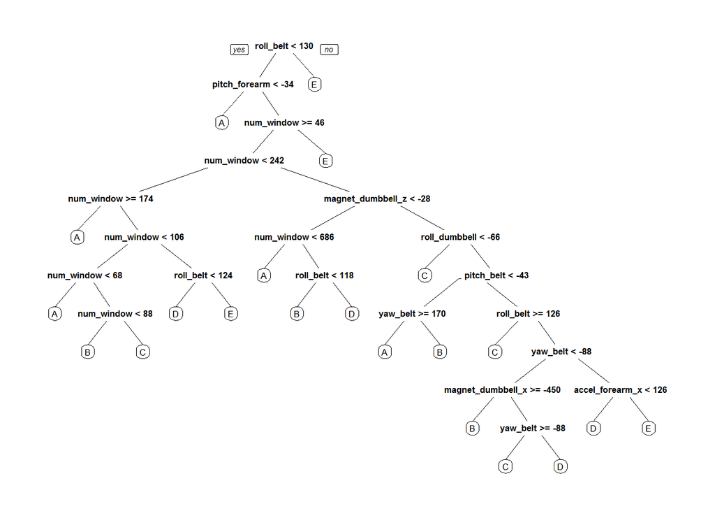

```r
rpartModel <- rpart(classe~., data=myTrain, method="class")
prp(rpartModel)
```

```r
predictionsTree <- predict(rpartModel, myTest, type = "class")
confusionMatrixTree <- confusionMatrix(predictionsTree, myTest$classe)
confusionMatrixTree
```

```
## Confusion Matrix and Statistics
##
##           Reference
## Prediction    A    B    C    D    E
##          A 1961  121    1   33    8
##          B   57 1067   43   41  130
##          C   54  152 1098   63   21
##          D  152  160  193 1061  226
##          E    8   18   33   88 1057
##
## Overall Statistics
##
##                Accuracy : 0.7958
##                  95% CI : (0.7867, 0.8047)
##     No Information Rate : 0.2845
##     P-Value [Acc > NIR] : < 2.2e-16
##
##                   Kappa : 0.7427
##  Mcnemar's Test P-Value : < 2.2e-16
##
## Statistics by Class:
##
##                      Class: A Class: B Class: C Class: D Class: E
## Sensitivity            0.8786   0.7029   0.8026   0.8250   0.7330
## Specificity            0.9710   0.9572   0.9552   0.8886   0.9770
## Pos Pred Value         0.9233   0.7975   0.7911   0.5921   0.8779
## Neg Pred Value         0.9526   0.9307   0.9582   0.9628   0.9420
## Prevalence             0.2845   0.1935   0.1744   0.1639   0.1838
## Detection Rate         0.2499   0.1360   0.1399   0.1352   0.1347
## Detection Prevalence   0.2707   0.1705   0.1769   0.2284   0.1535
## Balanced Accuracy      0.9248   0.8300   0.8789   0.8568   0.8550
```

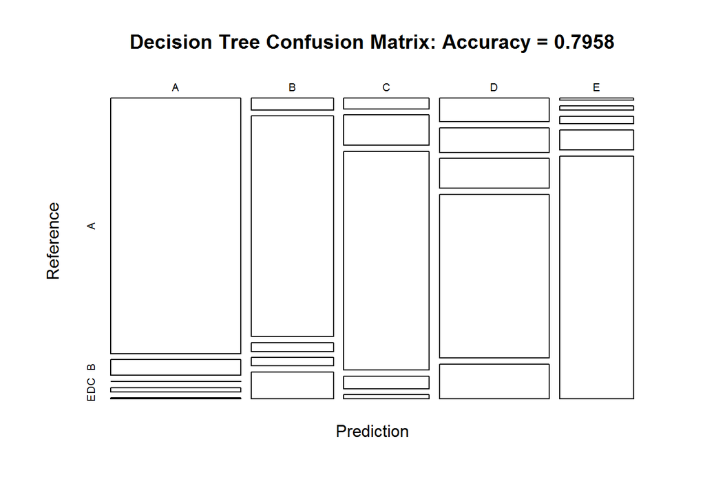

```r
plot(confusionMatrixTree$table, col = confusionMatrixTree$byClass, main = paste("Decision Tree Confusion Matrix: Accuracy =", round(confusionMatrixTree$overall['Accuracy'], 4)))
```

The second model that we will use is the Random Forest and we will calculate the model accuracy using the confusionMatrix function.

```r
set.seed(12345)
randomForestModel <- randomForest(classe ~ ., data=myTrain)
predictionsRandomForest <- predict(randomForestModel, myTest, type = "class")
confusionMatrixRF <- confusionMatrix(predictionsRandomForest, myTest$classe)
confusionMatrixRF
```

```
## Confusion Matrix and Statistics
##
##           Reference
## Prediction    A    B    C    D    E
##          A 2232    4    0    0    0
##          B    0 1511    4    0    0
##          C    0    3 1364   13    0
##          D    0    0    0 1272    3
##          E    0    0    0    1 1439
##
## Overall Statistics
##
##                Accuracy : 0.9964
##                  95% CI : (0.9948, 0.9976)
##     No Information Rate : 0.2845
##     P-Value [Acc > NIR] : < 2.2e-16
##
##                   Kappa : 0.9955
##  Mcnemar's Test P-Value : NA
##
## Statistics by Class:
##
##                      Class: A Class: B Class: C Class: D Class: E
## Sensitivity            1.0000   0.9954   0.9971   0.9891   0.9979
## Specificity            0.9993   0.9994   0.9975   0.9995   0.9998
## Pos Pred Value         0.9982   0.9974   0.9884   0.9976   0.9993
## Neg Pred Value         1.0000   0.9989   0.9994   0.9979   0.9995
## Prevalence             0.2845   0.1935   0.1744   0.1639   0.1838
## Detection Rate         0.2845   0.1926   0.1738   0.1621   0.1834
## Detection Prevalence   0.2850   0.1931   0.1759   0.1625   0.1835
## Balanced Accuracy      0.9996   0.9974   0.9973   0.9943   0.9989
```

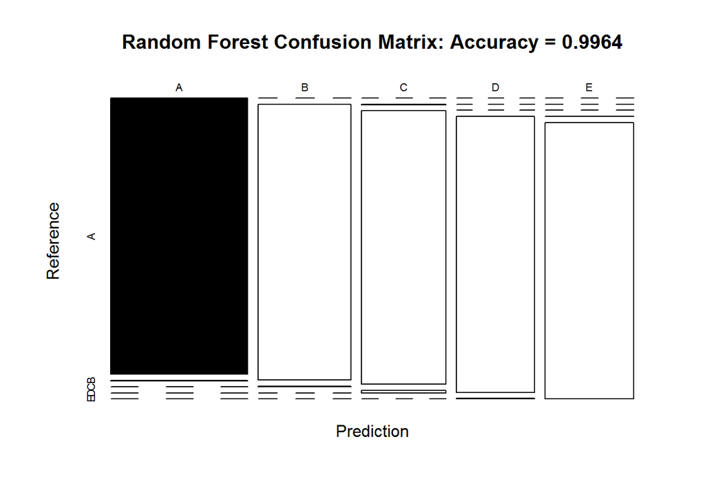

```r
plot(confusionMatrixRF$table, col = confusionMatrixRF$byClass, main = paste("Random Forest Confusion Matrix: Accuracy =", round(confusionMatrixRF$overall['Accuracy'], 4)))
```

## Selected Data Model

Based on the accuracy results from the previous calculations for both Decision Tree and Random Forest algorithms we will select the Random Forest algorithm and we will use the train() function from caret library to generate the final used model.

Beacuse the train function is using a lot of computer power processing, we will save the model into a file, that can be used later.

```r
set.seed(12345)
finalModel <- train(classe~.,
                  data=myTrain,
                  method="rf",
                  trControl=trainControl(method="cv",number=2),
                  prox=TRUE,
                  verbose=TRUE,
                  allowParallel=TRUE)

saveRDS(finalModel, "finalModelPML.Rds")

finalPredictions <- predict(finalModel, newdata=myTest)
confusionMatrixFinal <- confusionMatrix(finalPredictions, myTest$classe)
confusionMatrixFinal
```

```
## Confusion Matrix and Statistics
##
##           Reference
## Prediction    A    B    C    D    E
##          A 2232    2    0    0    0
##          B    0 1511    2    0    2
##          C    0    5 1366   10    0
##          D    0    0    0 1276    3
##          E    0    0    0    0 1437
##
## Overall Statistics
##
##                Accuracy : 0.9969
##                  95% CI : (0.9955, 0.998)
##     No Information Rate : 0.2845
##     P-Value [Acc > NIR] : < 2.2e-16
##
##                   Kappa : 0.9961
##  Mcnemar's Test P-Value : NA
##
## Statistics by Class:
##
##                      Class: A Class: B Class: C Class: D Class: E
## Sensitivity            1.0000   0.9954   0.9985   0.9922   0.9965
## Specificity            0.9996   0.9994   0.9977   0.9995   1.0000
## Pos Pred Value         0.9991   0.9974   0.9891   0.9977   1.0000
## Neg Pred Value         1.0000   0.9989   0.9997   0.9985   0.9992
## Prevalence             0.2845   0.1935   0.1744   0.1639   0.1838
## Detection Rate         0.2845   0.1926   0.1741   0.1626   0.1832
## Detection Prevalence   0.2847   0.1931   0.1760   0.1630   0.1832
## Balanced Accuracy      0.9998   0.9974   0.9981   0.9959   0.9983
```

## Cross validation and estimation of the out-of-sample error rate

The estimate out-of-sample error rate for the Random Forest algorithm can be calculated using the formula (100-Accuracy rate).

In our case the value will be 0.31%

The code to calculate the out-of-sample error rate is

```r
calculate_OOS_error_rate = function(values, predicted) {
  sum(predicted != values) / length(values)
}

OOS_error_Rate = calculate_OOS_error_rate(myTest$classe, finalPredictions)
OOS_error_Rate
```

```
## [1] 0.003058884
```

From the above numbers and calculations the expected and calculated out-of-sample error rates are close.

## Project Submissions

We will predict the classification of the observations of the testing data and generate the response files. The files will be manualy submited.

```r
predictionSubmission <- predict(finalModel, newdata=testing)
testing$classe <- predictionSubmission
answers = testing$classe

answers
```

```
##  [1] B A B A A E D B A A B C B A E E A B B B
## Levels: A B C D E
```

```r
pml_write_files = function(x){
  n = length(x)
  for(i in 1:n){
    filename = paste0("problem_id_",i,".txt")
    write.table(x[i],file=filename,quote=FALSE,row.names=FALSE,col.names=FALSE)
  }
}

pml_write_files(answers)
```